# Pset 5 - Plotly, Shiny, Interactions, Splines - Part 1 and 2

Author

Marie Ramm

```r
library(leaflet)
library(sf)
library(sp)
library(splines)
library(tidyverse)
library(pubtheme)
```

Objectives

- Continued data exploration of US Census data and CT property values data using interactive visualization libraries like `leaflet`, `plotly` and `shiny`
- Include Interaction terms in a linear model
- Include spline terms in a linear model

# Choosing a home location

A prospective homeowner is interested in buying a house in Connecticut. Since she works in New York City near Grand Central Terminal and her partner works in New Haven, she has the following preferences for the location of her new home:

- between NYC and New Haven,
- relatively close to a Metro-North train station,
- special preference towards stations with many options for convenient trains traveling to Grand Central Station and New Haven.

She also prefers to live in a town where

- the house prices aren’t *that* high, and
- the population is relatively diverse, and where at least 5% of the population is Asian.

## 1. Visualization

Create an interactive visualization or visualizations that she can use to help her make her decision. Use the data below, which contains

- US Census data (same as what we previously used in class)
- Latitude/longitude for Metro-North stations.
- For every pair of stations, information about trips between those two stations: number of trips, the mean duration, and the minimum duration. This has been filtered so that only trips to/from Grand Central, to/from New Haven, and along the train lines that are in Connecticut (New Haven Line, Danbury Line, Waterbury Line, New Canaan Line) remain.

Here is the data with some light cleaning to help you get started.

### Census data

```r
dc = readRDS('data/tracts.and.census.with.EV.stations.rds')
dc = dc[dc$state == 'CT',]
head(dc@data,2)
```

```
      STATEFP COUNTYFP TRACTCE             AFFGEOID       GEOID NAME LSAD
12844      09      001  090300 1400000US09001090300 09001090300  903   CT
12845      09      001  090400 1400000US09001090400 09001090400  904   CT
        ALAND AWATER  meters    miles state tract           county  state.full
12844 4764507      0 4764507 1.839586    CT   903 Fairfield County Connecticut
12845 7347827      0 7347827 2.837012    CT   904 Fairfield County Connecticut
       pop male female  age male.age female.age white black indian.alaskan
12844 4611 2333   2278 42.9     42.7       43.1  4230    24              0
12845 6518 3355   3163 40.6     36.5       45.7  4742   654             78
      asian pacific other two.or.more white.not.hisp hisp white.hisp black.hisp
12844   180       0    66         111           3888  435        342          0
12845   524      24    88         408           4324  613        418          0
      households i10orless i10to14 i15to19 i20to24 i25to29 i30to34 i35to39
12844       1550        56       8      22      34      16      12      31
12845       2140        24      18      85       0      89      36      49
      i40to44 i45to49 i50to59 i60to74 i75to99 i100to124 i125to149 i150to199
12844      19      43      59      67     231       204       197       261
12845       0      94      24     128     219       343       233       421
      i200ormore hh.income house.value   male.p female.p  white.p    black.p
12844        290    118819      372100 50.59640 49.40360 91.73715  0.5204945
12845        377    121802      344600 51.47284 48.52716 72.75238 10.0337527
       asian.p   hisp.p white.not.hisp.p white.hisp.p black.hisp.p  other.p
12844 3.903709 9.433962         84.32010     7.417046            0 3.838647
12845 8.039276 9.404725         66.33937     6.413010            0 9.174593
      rescaled.house.value hh.income.and.house tot.hh.income tot.house.value
12844             80487.25            99653.12     184169450       576755000
12845             76759.97            99280.99     260656280       737444000
      tot.hh.income.and.house pop.density hh.density income.density
12844               154462344    2506.542   842.5807      100114594
12845               212461309    2297.488   754.3148       91877050
      house.value.density house.and.income.density lev2 lev3
12844           313524273                 83965798    2    4
12845           259936875                 74889116   NA   NA
```

### Train stations

```r
st = read.csv('data/stops.txt')
st = st %>%
  select(stop_id, stop_code, stop_name, stop_lat, stop_lon)
head(st)
```

```
  stop_id stop_code          stop_name stop_lat  stop_lon
1       1       0NY      Grand Central 40.75300 -73.97706
2       4       0HL      Harlem-125 St 40.80516 -73.93915
3     622       0YS   Yankees-E 153 St 40.82530 -73.92990
4     184       0HI    Highbridge Yard 40.83590 -73.93150
5       9       0MH     Morris Heights 40.85425 -73.91958
6      10       0UH University Heights 40.86225 -73.91312
```

### Trips

```r
tr = readRDS('data/trips.rds')
tr = tr %>%
  arrange(stop1, stop2)
head(tr, 10)
```

```
         stop1   tf         stop2    n      mean min
1       Bethel from Grand Central  246 110.19919 104
2       Bethel   to Grand Central  188 117.61702 112
3  Branchville from Grand Central  246  94.19919  88
4  Branchville   to Grand Central  188 100.61702  95
5   Bridgeport from Grand Central 3024  90.20602  73
6   Bridgeport   to Grand Central 2920  98.40651  77
7   Bridgeport   to     New Haven 3066  34.35486  25
8   Bridgeport from     New Haven 2804  25.17511  20
9   Cannondale from Grand Central  246  87.19919  81
10  Cannondale   to Grand Central  188  93.61702  88
```

```r
# Just for New Haven/Fairfield as S. CT counties
dcs = dc[dc@data$county == 'New Haven County' | dc@data$county == 'Fairfield County', ]

dcsa = dcs[dcs@data$asian.p >= 5,]

# ADD CT TRAIN STOPS
ctlines = unique(tr$stop1)
st1 = st %>%
  filter(stop_name %in% ctlines)

#add avg time to NH and to GC to st1

trNH =  tr %>%
  filter(stop2 == "New Haven", tf == 'to')

timeNH = trNH %>%
  select(stop1, mean) %>%
  rename(stop_name = stop1, mean_nh = mean)

st2 = st1 %>%
  left_join(timeNH, by = "stop_name")

trGC =  tr %>%
  filter(stop2 == "Grand Central", tf == 'to')

timeGC <- trGC %>%
  select(stop1, mean, n) %>%
  rename(stop_name = stop1, mean_gc = mean)

st2 = st2 %>%
  left_join(timeGC, by = "stop_name")
```

### Visualizations

**Create your visualization(s) here.**

This is my first visualization which shows the stops along the way, sized according to number of trips and with information on the average trip duration to Grand Central and New Haven. Each census tract is filled according to the asian population percentage

```r
#CREAT FILL BASED ON ASIAN POPULATION
#COLOR PALETTE
pal1 = colorNumeric(palette = c(pubbackgray,
                                pubblue),
                    domain = NULL)

#CREATE LABEL
dcs$label = paste0('<b>GEOID: ', dcs$GEOID, '</b><br>',
                      'County: ', dcs$county, '<br>',
                      'Population: ', dcs$pop, '<br>',
                      'Percentage Asian Population: ', round(dcs$asian.p, 2),'<br>')


st2$label = paste0('<b>Station: ', st2$stop_name, '</b><br>',
                   'Mean Time to Grand Central: ', round(st2$mean_gc,0), '<br>',
                   'Mean Time to New Haven: ', round(st2$mean_nh,0), '<br>')


l1 = leaflet(dcs) %>%
  addTiles() %>%
  addPolygons(fillColor = ~pal1(asian.p),
              label = ~label %>% lapply(htmltools::HTML),
              weight = 0.5,
              color = 'black',
              fillOpacity = 0.7) %>%

  setView(lng = -72.79458,
          lat = 41.51979,
          zoom = 9) %>%

  addCircleMarkers(data = st2,
                   lng = ~stop_lon,
                   lat = ~stop_lat,
                   popup = 'point',
                   stroke = FALSE,
                   fillOpacity = .8,
                   fillColor = 'blue',
                   label = ~label %>% lapply(htmltools::HTML),
                   radius = ~sqrt(n) / 10) %>%
  addTiles()
l1
```

[interactive chart not shown]

I asked chatGTP to help size the dots after number of trips on 2/17/2025 and it recommended ~sqrt(n) / 10.

I also created this visualization that only shows the census tracts where the asian population is greater than 5% and then each census tract is filled according to median house value. This seemed like a better visualization for the purpose.

```r
dcsa$label = paste0('<b>GEOID: ', dcsa$GEOID, '</b><br>',
                      'County: ', dcsa$county, '<br>',
                      'Population: ', dcsa$pop, '<br>',
                     'Percentage Asian Population: ',
                      round(dcsa$asian.p, 2),'<br>',
                      'Median House Value: ', round(dcsa$house.value, 2),'<br>')
l3 = leaflet(dcsa) %>%
  addTiles() %>%
  addPolygons(fillColor = ~pal1(house.value),
              label = ~label %>% lapply(htmltools::HTML),
              weight = 0.5,
              color = 'black',
              fillOpacity = 0.8) %>%

  setView(lng = -72.79458,
          lat = 41.51979,
          zoom = 9) %>%

  addCircleMarkers(data = st2,
                   lng = ~stop_lon,
                   lat = ~stop_lat,
                   popup = 'point',
                   stroke = FALSE,
                   fillOpacity = .8,
                   fillColor = 'blue',
                   label = ~label %>% lapply(htmltools::HTML),
                   radius = ~sqrt(n) / 10) %>%
  addTiles()
l3
```

[interactive chart not shown]

## 2. Explanation

Briefly explain the choices you made for your visualization(s). What do you think the prospective homeowner will find most useful? Are there any locations in particular that stand out?’

The leaflet visualization lets the prospective homeowner get an initial overview of which stations are the biggest along the line. Then when they hover above each train station they can see the mean travel time to Grand Central and to New Haven. The only census tracts outlines and visible on the map are the tracts where the asian population is greater than 5$. Each tract is then filled according to median house value for which the specific value can be seen when hovering over the census tract.

It will be helpful for the home owner to first see the stations and the travel times before then being able to get more details on the census tracts around the stations.

For me, the census tracts just around Stamford stand out for 3 reasons. The first being that Stamford is a major station with many trips to both Grand Central and New Haven. Each trip takes on average 63 & 75 minutes respectively, making it a good compromise for the commute in both directions. Just around Stamford there are also several census tracts with an asian population greater than 5%. In these census tracts, there are some where the median house value is not high comparedly to other tracts, as long as you don’t move to close to the tracts around Greenwich in the New York Direction.

## Shiny

### 3. Basic Shiny App

Do the following to create a basic shiny app and publish it to shinyapps.io

- Configure R Studio to communicate with shinyapps.io by following the directions from this page https://shiny.rstudio.com/articles/shinyapps.html up to and including the “Method 1” section. You will show you how to install `rsconnect`, create a shinyapps.io account, and set up communication between R Studio and shinyapps.io. Note that you will only have to do this once.
- Create a new shiny app like we did in class by clicking File, New File, Shiny Web App. Name the app `pset5app1`, choose Single File, choose an appropriate directory, and click Create. An `app.R` file will open in R Studio.
- Click Run App to see the app. The app should appear in the Viewer tab in R Studio, or in its own window.
- In the upper right of the app, click Publish. Make sure the correct files and account are selected. Click Publish in the lower right.

Paste the url for your app here. The url will be of the form [https://yourusername.shinyapps.io/pset5app1/](https://yourusername.shinyapps.io/yourappname/)

[**url here**](https://marier791.shinyapps.io/pset5app1/)

### 4. Shiny App for choosing home location

Create a Shiny app that contains visualization you made in #1, and add at least one widget that allow the user to investigate the data by customizing the visualization in some useful way. For example, you could add a `sliderInput` or `selectInput` that helps you filter the data, or a `selectInput` that allows the user to choose how to color the points, etc.

Different types of user inputs can be found here https://shiny.rstudio.com/gallery/widget-gallery.html

Publish your shiny app to shinyapps.io, and paste the url for your app here:

I was unable to get my app to run successfully as it would get stuck at “Listening on http://127.0.0.1:7821” but then never showing my visualization. I’ve attached pictures of my shiny app code as I still think it is relevant.

```r
library(shiny)
library(dplyr)
library(leaflet)
library(sf)
library(tidyverse)
library(sp)
library(pubtheme)
library(ggplot2)

dc = readRDS('data/tracts.and.census.with.EV.stations.rds')
st = read.csv('data/stops.txt')
tr = readRDS('data/trips.rds')

# Define UI for application that draws a histogram
ui <- fluidPage(

    # Application title
    titlePanel("Where Should I Live?"),

    # Sidebar with a slider input for number of bins
    sidebarLayout(
        sidebarPanel(
            sliderInput("asian.p.input",
                        "Asian Population:",
                        min = 0,
                        max = 100,
                        value = 5),
            # sliderInput("house.value.input",
             #            "Median House Value:",
              #           min = 55500,
               #          max = 2000001 ,
                #         value = 247400)
        ),

        # Show a plot of the generated distribution
        mainPanel(
           plotOutput("mymap")
        )
    ))

# Define server logic required to draw a histogram
server <- function(input, output) {

    output$mymap = renderLeaflet({

      ´
      dcs = dc[dc@data$state == 'CT' &
              (dc@data$county == 'New Haven County' |
                 dc@data$county == 'Fairfield County'), ]

      pal1 = colorNumeric(palette = c(pubbackgray,
                                      pubblue),
                          domain = NULL)

      dcsa = dcs[dcs@data$asian.p >= input$asian.p.input, ]

      st = st %>%
        select(stop_id, stop_code, stop_name, stop_lat, stop_lon)

      tr = tr %>%
        arrange(stop1, stop2)

      st1 = st %>%
        filter(stop_name %in% unique(tr$stop1))

      timeNH = tr %>%
        filter(stop2 == "New Haven", tf == 'to') %>%
        select(stop1, mean) %>%
        rename(stop_name = stop1, mean_nh = mean)

      st2 = st1 %>%
        left_join(timeNH, by = "stop_name")

      timeGC = tr %>%
        filter(stop2 == "Grand Central", tf == 'to') %>%
        select(stop1, mean, n) %>%
        rename(stop_name = stop1, mean_gc = mean)

      st2 = st2 %>%
        left_join(timeGC, by = "stop_name")

      st2$label = paste0('<b>Station: ', st2$stop_name, '</b><br>',
                         'Mean Time to Grand Central: ', round(st2$mean_gc,0), '<br>',
                         'Mean Time to New Haven: ', round(st2$mean_nh,0), '<br>')

      lat = 41.316
      lng = -72.922

      dcsa$label = paste0('<b>GEOID: ', dcsa@data$GEOID, '</b><br>',
                          'County: ', dcsa@data$county, '<br>',
                          'Population: ', dcsa@data$pop, '<br>',
                          'Percentage Asian Population: ',
                          round(dcsa@data$asian.p, 2),'<br>',
                          'Median House Value: ', round(dcsa@data$house.value, 2),'<br>')

      p = leaflet() %>%
        addTiles() %>%
        addPolygons(data = dcsa,
                    fillColor = ~pal1(house.value),
                    label = ~label %>% lapply(htmltools::HTML),
                    weight = 0.5,
                    color = 'black',
                    fillOpacity = 0.7) %>%
        addCircleMarkers(data = st2,
                         lng = ~stop_lon,
                         lat = ~stop_lat,
                         popup = 'point',
                         stroke = FALSE,
                         fillOpacity = .8,
                         fillColor = 'blue',
                         label = ~label %>% lapply(htmltools::HTML),
                         radius = ~sqrt(n) / 10) %>%
        addTiles() %>%
        setView(lng = lng,
                lat = lat,
                zoom = 15)
      return(p)

    })
}

# Run the application
shinyApp(ui = ui, server = server)
```

Summarize in a sentence why you choose those user inputs and what you learned about the data from the app.

# CT Property data

First let’s load the CT property and keep only the New Haven properties.

```r
d = readRDS('data/coast.properties.rds')
d = st_drop_geometry(d)

## I'm gonna change some column names
colnames(d) = gsub('_', '.', colnames(d))

colnames(d)[colnames(d) == 'Assessed.Total'] = 'value'
colnames(d)[colnames(d) == 'Number.of.Bedroom'] = 'beds'
colnames(d)[colnames(d) == 'Number.of.Baths'] = 'baths'
colnames(d)[colnames(d) == 'Number.of.Half.Baths'] = 'half.baths'
colnames(d)[colnames(d) == 'Living.Area'] = 'living'
colnames(d)[colnames(d) == 'SHAPE.Area'] = 'land'
colnames(d)[colnames(d) == 'Condition.Description'] = 'cond'
colnames(d)[colnames(d) == 'State.Use.Description'] = 'use'
colnames(d)[colnames(d) == 'GlobalID'] = 'id'
colnames(d)[colnames(d) == 'Mailing.Address'] = 'address'
colnames(d)[colnames(d) == 'Mailing.City'] = 'city'
colnames(d)[colnames(d) == 'Town.Name'] = 'town'
colnames(d)[colnames(d) == 'Valuation.Year'] = 'val.year'
colnames(d)[colnames(d) == 'Sale.Price'] = 'sale.price'
colnames(d)[colnames(d) == 'Sale.Date'] = 'sale.date'
colnames(d)[colnames(d) == 'AYB'] = 'ayb'
colnames(d)[colnames(d) == 'EYB'] = 'eyb'

d = d %>%

  filter(value != 0,
         grepl('Single Fam|SINGLE FAM|One Fam|ONE FAM',
               use),
         Qualified == 'Q',
         sale.price != 0,
         !is.na(living),
         living != 0,
         Condition %in% c( 'E', 'EX',             ## excellent
                           'VG', 'G', 'GD',       ## very good, good
                           'A+', 'A', 'AV', 'A-', ## avg+, avg, avg-
                           'F', 'FR',             ## fair
                           'P', 'VP' ),           ## poor, v poor
         !duplicated(id)) %>%

  mutate(cond = case_when(cond == 'EX' ~ 'Excellent',
                          cond == 'Avarage' ~ 'Average',
                          cond == 'AV' ~ 'Average',
                          cond == 'F' ~ 'Fair',
                          cond == 'FR' ~ 'Fair',
                          cond == 'GD' ~ 'Good',
                          cond == 'G+' ~ 'Very Good',
                          TRUE ~ cond),

         dist = as.numeric(dist),
         land = ifelse(land < 0, -land, land)) %>%

  select(value, living, land,
         beds, baths, half.baths,
         cond, use, dist, ayb, eyb,
         sale.price, sale.date,
         address, city, town, id,
         centroid.x, centroid.y,
         point.x, point.y)

d = d %>%
  filter(town == 'NEW HAVEN')
```

## 5. Data exploration with `ggplotly` and `plotly`

Recall we noticed what looks like two distinct clouds of points in this visualization.

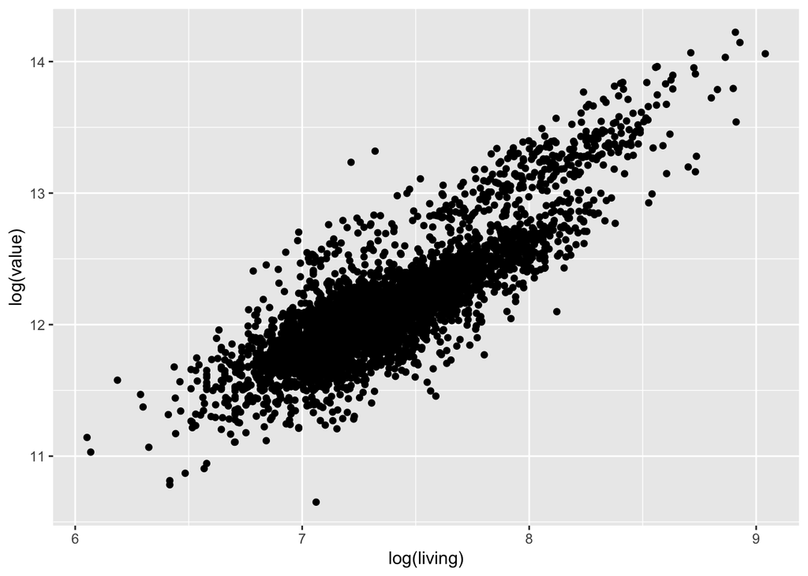

```r
g = ggplot(d,
       aes(x = log(living),
           y = log(value))) +
  geom_point()

g
```

Use `ggplotly` or `plotly` to make a interactive scatter plot of `log(value)` vs `living`. Add color, tooltip, or other features that help you investigate why there appears to be two distinct clouds of points. What characteristics do the properties in the upper right cluster of points have in common?

```r
#install package to calculate distance on sphere
library(geosphere)

# Add col of distance from point in east rock
d = d %>%
  mutate(distER = distHaversine(cbind(centroid.x, centroid.y),
                                  c(-72.911989, 41.322032)) / 1000)

# create science hill grouping of properties within 2km of point
d = d %>%
  mutate(eastrock = ifelse(distER <= 1,
                        "yes",
                        'no')) %>%
  filter(!is.na(eastrock))

d = d %>%
  mutate(eastrock = as.factor(eastrock))

# Create label
d = d %>%
  mutate(label = paste0('Address: ', address, '<br>',
                        'In East Rock?: ', eastrock, '<br>'))

g3 = ggplot(d,
       aes(x = log(living),
           y = log(value),
           text = label,
           color = distER)) +
  geom_jitter(alpha = 0.3) +
  geom_point(alpha = 0.1) +
  labs(title = "log(value) ~ log(living) of New Haven Properties",
       color = "Proximity to East Rock") +
  scale_color_viridis_c() +
  theme_pub()

#g3

g4 = ggplot(d,
       aes(x = log(living),
           y = log(value),
           text = label,
           color = eastrock)) +
  geom_jitter(alpha = 0.3) +
  geom_point(alpha = 0.1) +
  geom_smooth(method = 'lm',
              aes(group = eastrock),
              se = FALSE) +
  labs(title = "log(value) ~ log(living) of New Haven Properties",
       color = "Within 1km of East Rock") +
  theme_pub()

#g4


## Interactive plot_ly plot
gg1 = g3 %>%
  ggplotly(tooltip = c('x', 'y', 'text'))
gg1
#is(gg)

gg2 = g4 %>%
  ggplotly(tooltip = c('x', 'y', 'text'))
gg2
```

[interactive chart not shown]

As can be seen in the 2 plots, the points in the upper right cluster are primarily within 1 km of East Rock (I choose the intersection of Orange and Willow St. as the center of East Rock)

## 6. Data exploration with `leaflet`

Use `leaflet` to make an interactive map of the properties. Add color, tooltips, or other features that helps you further investigate why there are two clouds of points. Does this map confirm your conclusions from the previous question?

```r
# For simplicity, I'm going to make an interactive map on properties around NH
d.nh = d %>%
  filter(point.x >  -73.0608, point.y > 41.2287,
         point.x <  -72.692774, point.y < 41.394657)
head(d.nh)

d.nh$label = paste0('<b>Address: ', d.nh$address, '</b><br>',
                      'Property Value: ', d.nh$value, '<br>',
                      'Living Area: ', d.nh$living, '<br>',
                      'Condition: ', d.nh$cond,'<br>',
                    'In East Rock?: ', d.nh$eastrock, '<br>' )


l4 = leaflet(data = d.nh) %>%
  addTiles() %>%
  addCircleMarkers(lng = ~centroid.x,
                   lat = ~centroid.y,
                   popup = 'centroid',
                   stroke = FALSE,
                   fillOpacity = .8,
                   fillColor = ~pal1(log(value)),
                   label = ~label %>% lapply(htmltools::HTML),
                   radius = 3) %>%
  addCircles(lng = -72.911989,
             lat = 41.322032,
             radius = 1000,
             color = "black",
             weight = 1,
             fillOpacity = 0.3,
             popup = "1km Radius from East Rock")

l4
```

```
        value living      land beds baths half.baths    cond           use dist
754264 199430   1792 1303.4148    3     2          1 Average Single Family  330
754265 161000    864 2986.3171    3     1          0    Good Single Family  321
754269 133000   1040  976.3963    2     1          0 Average Single Family  266
754285 141680    998  895.4412    2     1          0    Good Single Family  319
754287 171640   1680  875.4209    4     1          0 Average Single Family  346
754290 154420   1144  926.6353    3     1          0 Average Single Family  323
        ayb  eyb sale.price           sale.date           address      city
754264 1989 2003     140000 2001-12-30 19:00:00       11 URIAH ST NEW HAVEN
754265 1945 1999     183000 2004-07-28 20:00:00  181 SOUTH END RD NEW HAVEN
754269 1930 1989     142000 2011-06-23 20:00:00 161  SOUTH END RD NEW HAVEN
754285 1940 1999     189000 2021-01-21 19:00:00   17 DOUGLASS AV  NEW HAVEN
754287 1940 1989     245000 2006-07-02 20:00:00    29 DOUGLASS AV NEW HAVEN
754290 1969 1989     180000 2017-10-25 20:00:00   577 WHALLEY AVE NEW HAVEN
            town                                     id centroid.x centroid.y
```

[output cut: 20 more lines]

[interactive chart not shown]

This does indeed confirm my conclusions from the plotly graphs as we can see that the darkest dots (highest log(value)) are the points within the 1 km circle of the intersection of Orange and Willow St.